# Practical Machine Learning Project

azhubryd

Thursday, June 18, 2015

In this project machine learning algorithms are applied for the problem of determination of activity performed. Different methods are applied and analysed in order to generate an accurate prediction. Tree-based methods turned out to be the most accurate for this dataset.

## Data Processing

First, we load required libraries, download and open the datasets.

```r
download.file(url = 'https://d396qusza40orc.cloudfront.net/predmachlearn/pml-training.csv', 'training.csv')
download.file(url = 'https://d396qusza40orc.cloudfront.net/predmachlearn/pml-testing.csv', 'testing.csv')
```

```r
data <- read.csv('training.csv')
validate <- read.csv('testing.csv')
```

To develop reliable and precise prediction we will split our **training.csv** dataset into 2 subsets: **training**, on which we will train algorithms, and **testing**, which will help us to determine the best prediction algoritmh. Also, we create a small sample called **test5**, which consists of only complete cases.

```r
set.seed(1234)
inTrain <- createDataPartition(y = data$classe,p = 0.7,list = FALSE)
training <- data[inTrain,]
testing <- data[-inTrain,]
test5 <- data[complete.cases(data),]
```

Now, let’s take a look at the **training** dataset:

```r
dim(training)
```

```
## [1] 13737   160
```

```r
str(training[,1:10])
```

```
## 'data.frame':    13737 obs. of  10 variables:
##  $ X                   : int  2 3 4 5 6 7 8 9 10 11 ...
##  $ user_name           : Factor w/ 6 levels "adelmo","carlitos",..: 2 2 2 2 2 2 2 2 2 2 ...
##  $ raw_timestamp_part_1: int  1323084231 1323084231 1323084232 1323084232 1323084232 1323084232 1323084232 1323084232 1323084232 1323084232 ...
##  $ raw_timestamp_part_2: int  808298 820366 120339 196328 304277 368296 440390 484323 484434 500302 ...
##  $ cvtd_timestamp      : Factor w/ 20 levels "02/12/2011 13:32",..: 9 9 9 9 9 9 9 9 9 9 ...
##  $ new_window          : Factor w/ 2 levels "no","yes": 1 1 1 1 1 1 1 1 1 1 ...
##  $ num_window          : int  11 11 12 12 12 12 12 12 12 12 ...
##  $ roll_belt           : num  1.41 1.42 1.48 1.48 1.45 1.42 1.42 1.43 1.45 1.45 ...
##  $ pitch_belt          : num  8.07 8.07 8.05 8.07 8.06 8.09 8.13 8.16 8.17 8.18 ...
##  $ yaw_belt            : num  -94.4 -94.4 -94.4 -94.4 -94.4 -94.4 -94.4 -94.4 -94.4 -94.4 ...
```

As we see, it contains 160 columns, which is quite a lot. We want to decrease this number and leave more significant columns for our predicting algorithms. We will delete columns, which fall under at least one of the following rules:

- near zero variance (function **nearZeroVar** from **caret** package)
- columns with technical information: timestamps, rowid etc.
- column contains more than 90% of NAs

These analyses will be executed on the **training** dataset and applied for all the datasets: **training**, **testing** and **validate** (20 cases we have to predict).

```r
nrzero <- nearZeroVar(x = training,foreach = FALSE, freqCut = 95/5,uniqueCut = 10,saveMetrics = FALSE,allowParallel = TRUE)
technical <- c(1,3:5)
highNA <- which(colSums(is.na(training))/nrow(training) > 0.9)

toDelete <- unique(c(nrzero, technical, highNA))
length(toDelete)
```

```
## [1] 105
```

```r
# Checking if response variable 'classe' is among these variables
'classe' %in% names(training)[toDelete]
```

```
## [1] FALSE
```

```r
training <- training[,-toDelete]
testing <- testing[,-toDelete]
test5 <- test5[,-toDelete]
validate <- validate[,-toDelete]
dim(training)
```

```
## [1] 13737    55
```

So, 105 columns fall under our rules and can be removed and we’re left with only 54 predictive variables and 1 response *classe*.

## Algorithm Selection

Our training dataset is quite big: 13737 cases and 54 predictive variables. So, we’ll start from using **test5** dataset with only 406 cases to select a shortlist of methods, which later will be trained on the **training** dataset. As those calculation of long list of methods are very complex and messy, I’ll present just the results on the shortlist and most popular methods:

```
##    method  test5 training testing
## 1    C5.0 1.0000   0.8583  0.8629
## 2   ctree 0.7118   0.5490  0.5483
## 3     lda 0.7833   0.7052  0.7118
## 4      nb 0.7857   0.6814  0.6763
## 5 pcaNNet 0.8079   0.6076  0.6139
## 6      rf 1.0000   0.8706  0.8705
## 7   rpart 0.5690   0.5201  0.5108
## 8 treebag 1.0000   0.8315  0.8309
```

As we see from the **training** and **testing** datasets, performance of these methods is quite good if to take into account such small training sample. Although, *rpart* method didn’t perform very well, so only this method will be excluded from further calculations.

Next step is running a short list of 7 methods on the **training** dataset, which yeilded the following results:

```
##    method training testing
## 1    C5.0   1.0000  0.9995
## 2   ctree   0.9458  0.9093
## 3     lda   0.7491  0.7521
## 4      nb   0.7630  0.7512
## 5 pcaNNet   0.6398  0.6408
## 6      rf   1.0000  0.9981
## 7 treebag   1.0000  0.9966
```

We see an awesome performance of 3 methods:

- **C5.0** - boosted tree/rule-based algorithm
- **rf** - random forest
- **treebag** - bagged tree algotithm

These 3 methods are tree-based and show very high accuracy: **C5.0** method predicted incorrectly only *3* out of *5885* cases of **testing** dataset. We will use these 3 methods to predict values for **validate** dataset and check whether prediction for different methods are the same:

```r
validate_pred <- data.frame(C5.0 = predict(fit_C5.0, validate),
                            rf = predict(fit_rf, validate),
                            treebag = predict(fit_treebag, validate))
```

```r
with(validate_pred, all.equal(C5.0, rf, treebag))
```

```
## [1] TRUE
```

```r
validate_pred
```

```
##    C5.0 rf treebag
## 1     B  B       B
## 2     A  A       A
## 3     B  B       B
## 4     A  A       A
## 5     A  A       A
## 6     E  E       E
## 7     D  D       D
## 8     B  B       B
## 9     A  A       A
## 10    A  A       A
## 11    B  B       B
## 12    C  C       C
## 13    B  B       B
## 14    A  A       A
## 15    E  E       E
## 16    E  E       E
## 17    A  A       A
## 18    B  B       B
## 19    B  B       B
## 20    B  B       B
```

As all prediction from 3 methods are the same, we use them with practically full confidence. Also, we would like to visualize the accuracy of predictions for different levels of output and methods:

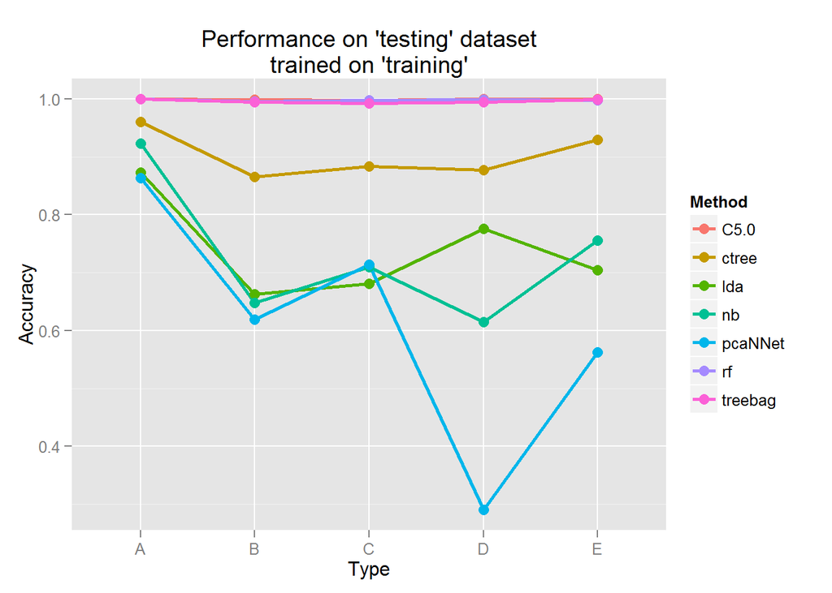

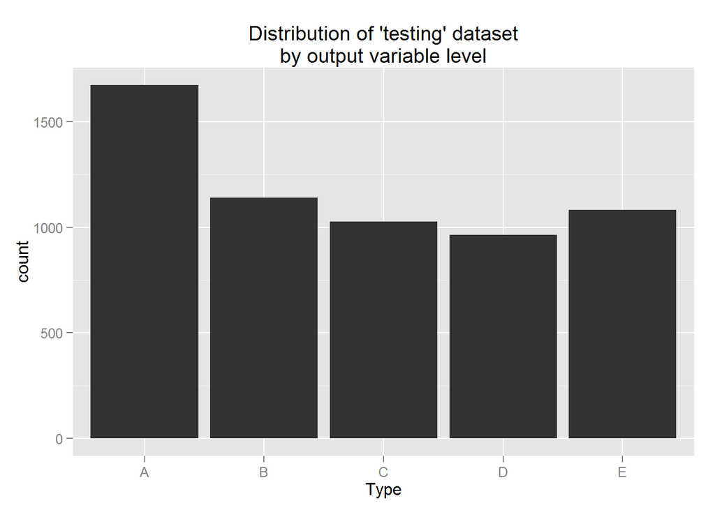

The biggest group - **A** - has the highest accuracy among all methods. Also, from the first figure we see 3 groups of methods for this data:

- **C5.0**, **rf** and **treebag**: our selected methods, which are very accurate
- **ctree**: accuracy of 0.9 and it’s tree-based methods (like our 3 selected)
- **pcaNNet**, **nb** and **lda**: accuracy of 0.65-0.75, not tree-based

We can conclude that tree-based methods are very suitable for this problem and show way better performance than other.